[figure not shown]

# Examinging Students’ Changing Approaches to Earth Data Science Problem Solving

The following data represent student responses to a set of questions related to their approach to solving a data science problem that deals with plotting average temperature data.

This report is interested in how students’ responses to this same set of items change over time as a result of gaining hands on Earth Data Science (EDS) experience through the Earth Data Analytics - Foundations Professional Certificate.

Students enrolled in the certificate program (2019-2021) were asked to respond to the following questions related to their EDS problem solving approach before and after the 1st course of the three-course sequence (*Earth Analytics Data Science Bootcamp*), at the end of the 2nd course (*Earth Analytics - Python*), and again following the 3rd course (*Earth Analytics Applications*).

#### *Describe your approach to data analysis*

*You have 32 text files that contain average daily temperature data for Boulder, Colorado over the last 32 years, stored in degrees Fahrenheit. Each text file contains 1 years worth of data. You need to calculate the monthly average temperature in degrees Celsius for each year and then plot temperature over time. Your final plot will look similar to:*

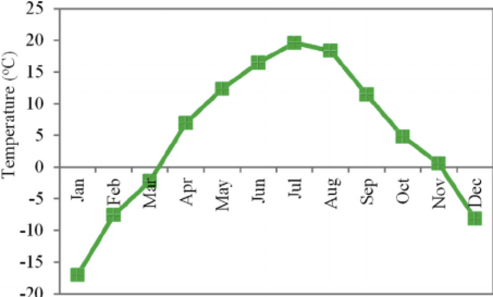

##### *Answer the following questions about this task:*

*1.) Select the tool that you would use to efficiently process these text files given your current skills and knowledge. (Select all that apply)*

*2.) Consider the tool(s) that you selected above - how comfortable are you implementing this task in that tool?*

*3.) Describe the steps (a step by step approach) that you would take to perform this analysis given the tools that you know how to use.*

## Earth Analytics Data Science Bootcamp

### Pre-Course Survey Responses

Here we begin by looking at responses from the survey taken *before* the *Earth Analytics Data Science Bootcamp* course (*pre-bootcamp*), the first time certificate students are asked about their EDS problem solving approaches. Since this question was first asked in the fall of 2019, a total of **70** students have answered the above set of questions on the *pre-bootcamp* survey.

##### *1.) Select the tool that you would use to efficiently process these text files given your current skills and knowledge. (Select all that apply):*

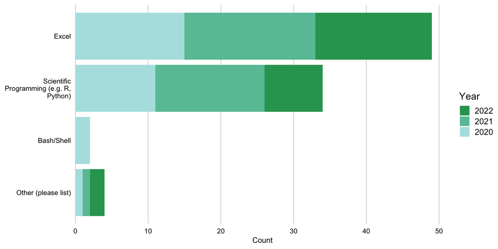

##### *Other (please list):*

| Matlab |
| --- |
| Not sure |
| Matlab |
| Igor |
| IDL |

##### *2.) Consider the tool(s) that you selected above - how comfortable are you implementing this task in that tool?*

Overall, respondents reported a relatively high level of comfort with these different EDS problem solving tools. In total, **19** students reported being *very comfortable* with the tools they listed in the previous question, with **39** saying they were *comfortable*. Fewer students reported lower levels of comfort with these tools, with **8** saying they were *uncomfortable*, and just **4** responding that they were *very uncomfortable*.

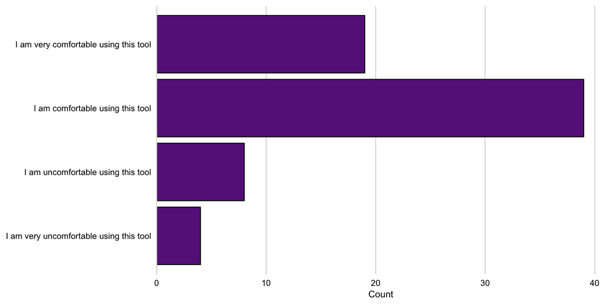

##### **3.) *Describe the steps (a step by step approach) that you would take to perform this analysis given the tools that you know how to use.***

Tabulated below are the written responses that students provided when asked to describe the step-by-step workflow that they would use to go about solving this problem using the tool(s) they selected above. While there are a number of responses that describe in some detail how to solve the problem outlined here using scientific programming (eg. R & Python), many of written descriptions that involved the use of Excel were quite brief and lacked detail. Notably, respondents indicated that they might first clean or organize the data using Excel before moving to R or Python to summarize and display the data, suggesting that Excel still plays a large role even for many of those students who had some experience with other scientific programming languages.

I really am not sure how to do this task with Python.

I imagine the first step would be to extract and organize the data in the text file.

I would enter all the data into excel and then use the tool to create a scatter plot reflecting all the data entered

The easiest thing for me to do would be to combine the data into one file in excel, bring it into R to manipulate using plyr/dplyr, and then to make the graph in R with ggplot. I could also do everything in excel but I think the manipulation would take me longer and the graph wouldn’t be as visually appealing. I could also do everything in R but I’m less comfortable with the steps to create a new data table and get all of the information in the same and correct place, and so I think it would take me longer to accomplish than in excel.

import files into R average the data in each file create a matrix of averages over year plot in R

I would first create a single dataframe with all of the data. Then I would write a formula that averaged each months’ temperatures. Lastly, I would plot it.

Uh oh… it’s been a while since I had to start anything from scratch and I wasn’t good at it then, but roughly…. * import a couple things (numpy, matplotlib, maybe others?) * count the lines and then pre-populate an array with zeroes * read in data files, looping through to open each file * read each line, split to make it into a list of (presumably) Y, M, D and daily mean T values & populate array * and then, I think, loop through all of the values for each month (e.g. all the January values for all the years, then all the Feb, etc) and get the np.mean for each month * And finally plt.plot the 12 values Most of the Python stuff I have done is work with other people’s way more complicated code to tweak it to get some plots to come out and don’t really understand it well. I’m going to be happy to start with the basics again and build up!

1. Ensure that folder containing .txt files ONLY contains text files (for peace of mind) and that all .txt files are formatted the same
2. Use jupyter notebook and os module to make a list of files
3. loop thru files using python and load into pandas dataframe
4. Find out what the equivalent of MAXIF is in pandas/python and use that
5. Mess around with the code to ensure it works
6. Draw graph using matplotlib

In Excel:

1. Import each text file into the spreadsheet.
2. Use the chart/graph functionality to create a plot.
3. Configure the layout of the plot.

in R set working directory to where the files are located look for files with the naming convention loop through the files importing each set of data and binding it to the last dataset order data by year, month and day perform some quality checks for missing days and gaps, out of range values derive temperature value in degrees C group cleaned data by year and month to calculate annual monthly mean plot mean data

Import the text files into excel spreadsheets, input a formula to calculate an average monthly temperature for each year, plot that data for each year, migrate the values for average monthly temperature for each year into a new excel sheet, plot the 32 years worth of average monthly temperatures in excel to find temperature change over time.

Use Import Tool feature in Matlab to get the data into workspace. Use IF functions to determine if temperature is Jan, Feb, etc. SUMIF (in Excel, not sure about Matlab) if TRUE and divide by days in month. Now you have array of temps and months to plot.

I would order each year of data into 12 cells in the same row. Do the same for each year creating 32 rows. Create a formula to calculate the average of each column.

R would be a useful tool, as it handles large data sets. All that you would need to do is create a simple function that will calculate monthly average temperatures. Then you would need to create another function that will take these averages from different files, on a repeating basis per folder.

I will convert text file to dataframes and plot data with matplot lib or I will save dataframe csv file and plot quickly with excel graphing tools.

Unsure

Organize the data by year in Excel, use the in program function for averaging. Then plot those averages in a scatter plot. Edit the plot so that the data axis are clearly labeled.

Don‚Äôt exactly remember how.

Add cells and divide over each month, and plot these values in the correct order.

i just know you can enter data into an Excel spreadsheet and make a plot from that. I haven’t done so in a couple years though

I would import the files into excel and create new vectors for each month. Then, average these vectors and convert them to Celsius. Next plot these values against time (month).

It’s been a little while, so I would definitely need to use some Google along the way, but, essentially:

read in .csv files to R 2)Make sure every text file uses the same headers for each month

calculate the mean for each month from each dataset

plot the mean temperature per month for the year

1. Load all text files into a data frame using R – each column will be a year and rows will represent a day’s average temperature. So, the data frame will have 365 rows and 32 columns.

Convert degrees Fahrenheit to degrees Celcius.

Create a date column (using as.Date) and calculate monthly temperature averages. (Ex: average of days 1-31 = January average temp).

you can now plot monthly temperature averages over time. The example graph looks like it’s for only one year or a 32-year average.

cell math

or script it for a bash shell

I know this is painstaking…

1)tabulate data by transposing so each row represents a years worth of data (365 or 366 columns 2) For bookkeeping I would add a blank column in between each month 3) Insert a couple blank rows at the top, and label the topmost cell in each blank column that follows a month as that month (Jan, Feb, etc…) 4) Below the Month label, make a cell that does an average function of all the data from the 31 rows (years) for each month 5) Make a plot with the top two rows (Month on the x axis, average value on the y) 6) Format plot to have appropriate symbology and line segments connecting data point 7) Troubleshoot deliverable as required

‘- loop through the 32 files in the directory, appending each year of data to a single pandas dataframe (assuming each temp value has a full date associated with it) - convert values to Celsius - ensure data type of date column is datetime to be able to identify or parse out the month (maybe make new column of just the month? would have to play with the date to know what works) - df.groupby(’month’).agg({‘temp’: ‘avg’}) - plot avg temp vs month using matplotlib

’- QA/QC [done in excel]: open text files to see how data are organized, if their formats match (same heading, delineation, etc), figure out how null values are notated and if they’re notated the same throughout, format any gaps in data so that they will be friendly to analysis, make sure months are displayed as numbers, etc

- import text text or excel files into matlab as arrays
- Figure out how to pull the month out of however the date is formatted in the text file, and add that as a row/column in all the arrays
- Combine all the arrays into one, big array
- Write some function to pull out all the temperature values from the big array to make little arrays for each month
- calculate the mean temperature for each month array, and probably throw some standard deviations in there
- combine all these values (date, mean temp, std dev) into a new array
- use matlab to plot the data
1. Search directory to build list of the 32 text files
2. With the list above as input to a for loop, read in the data from each year and populate a data frame where each row represents a specific date; perhaps iterate over each row of data being read in and append to the data frame?
3. In the same loop as above calculate average monthly values and add to a new data frame that would have one column for month and second column for value; different ways to do this depending on the source data such as selecting all values for a month and calculating average value or explicitly selecting rows for the ordinal day
4. Add a new column for temp in Celsius to data frame and calculate from F temperature values
5. Use MatplotLib to plot up month against C degrees temperature and export as image; perhaps use input filename to identify year?

Hopefully that’s not too much detail.

I would probably start in excel and make one giant spreadsheet with three columns: date, temp, and month. If month wasn’t already specified I would use text to columns to make it or else some other process. It would depend on the measurement interval, I guess.

Then I would import the giant spreadsheet into r. I would then create a dataframe and add a vector of months (months <- c(Jan, Feb, Mar…,Dec)). Then I would use subset function to make a new vector for each month of all the temps for that month. Maybe, jantemp <- subset(data, month = jan). I would do this in r and not excel because you would have to do annoying if statements or a lot of copy/paste in excel.

Next I would make a vector of all the means of the monthly temps meantemps <- c(mean(jantemp),mean(febtemp),…mean(dectemp).

Then finally plot(months ~ meantemps)

I would not be able to do this task.

I would begin by determining the format of the text file. Next, I would write a for loop to iterate over each file in my data directory (which stores each of the data files) and read the daily average temperatures from each file into a pandas data frame that can be indexed by month and year. Subsequently, I would iterate over each month and year in chronological data to select and average the monthly temperature data in this data frame, storing these average values in an array. Next, the Fahrenheit averages could be converted to Celsius averages with a call to a function that takes a numpy array as input and outputs the unit converted array. Finally, using a plotting library such as matplotlib, I would plot these monthly data averages.

# Import statements

import glob import matplotlib.pyplot as plt import os import pandas as pd

# Set proper current working directory

os.chdir(r’C:[remainder of path to current working directory]’)

# Import 32 text files to one consolidated DataFrame

all_data_df = pd.concat([pd.read_csv(file, sep=‘,’) for file in glob.glob("*.csv")], ignore_index=True)

# Create a new variable containing the daily temps in degrees Celsius

all_data_df[‘tempC’] = (all_data_df[‘tempF’] - 32) * (5/9)

# Set the date/time column as the DataFrame’s index

all_data_df.set_index(‘date_time’, inplace=True)

# Resample the data from daily temp observations to monthly avg temp (Celsius) observations

monthly_data_df = all_data_df[‘tempC’].resample(‘M’).mean()

# Plot temperature over time

ax = monthly_data_df.plot() ax.set_ylabel(‘Temperature (Celsius)’) plt.show()

I would convert the text files to comma delimited files, combine them, and try to write a formula that would average the temperature by month for each year and then convert degrees F to degrees C. Then I would create a plot with the averaged result for each month on the x-axis with degrees C on the y-axis.

First, I would hope the .txt files follow a consistent naming convention (and if not I’d probably manually rename them something along the lines of yyyy_temp).

I use RStudio, and would start a new script, load necessary packages, and navigate to the appropriate working directory. The command read.delim(“filename”) is used to read a text file. To make referring to a particular file easier, I’d name the dataframe: yytemps <- read.delim(“yyyy_temp”). I can now “see” the data using head(yytemps), which gives column names and the first few rows of data.

Because we want the plot to have temperatures in Celsius, I need to convert each value from Fahrenheit. I could probably do this by creating a vector with:

celsius <- (yytemps$fahrenheit - 32)* (5/9)

and then appending the vector as a column to the yytemps dataframe:

yytemps$celsius <- celsius

The function mean() is used to calculate averages. I need to specify arguments that tell it which data set to use and which column from that dataset. In order to get monthly averages rather than an annual mean, I also need to specify a range of rows (for each month). That code might look something like: yyjan <- mean(yytemps[1:31, 3]) where 1:31 specifies the rows containing data for January, and 3 specifies the column I added containing temperature data in celsius.

There might be a way to automate this so I don’t have to manually change the row numbers for each month, so I’d probably look into writing a conditional loop or maybe even a variation on the mean() function, but I don’t know how to do that off the top of my head (I’m sure there’s something on stackoverflow).

Otherwise, I’d just “brute force” it as above to get an average for each month, use ggplot2 to generate a plot of monthly avg temp (C) on the y-axis vs date (month) on the x-axis, and then run the script for each individual file (resulting in 32 plots and a whole mess of variables).

It’s not the most elegant solution, but it’s one I know would work.

For each file: Read temperatures to list of floats Calculate average using sum/len Convert to C Store in dict keyed to year

Read matplotlib docs for one millionth time Plot results in using matplotlib

Import text files into Excel, separate into columns/rows as needed. Create functions to average temp data by month and plot output. Repeat for each year (yuck) hence the need to learn other programs.

I would read the 32 files in R Merge them together using something like Rbind Summarize temperature by taking the mean for each month using dplyr group_by and summarise And then plot the values

import the files into excel get averages of the days in each month of each year get averages of the months from all the years plot these averages

1.import data into excel 2. merge the 32 files 3. take the average

1. Convert .txt file to .csv (likely consolidating into fewer files depending on characteristics of the data)
2. import to R
3. use R pkgs like dplyr and tidyr organize and summarize into monthly metrics
4. use R ggplot2 to generate figures
1. First, make sure all the files are in the same folder - then import the files into R using a custom function which would row bind the files together under the same column names
2. To sure time-series analysis can be done, I would asses the class of the date column and convert to a readable format for seasonality analysis using either base R or Lubridate
3. Now the table is organized in to a time series flat file, I would create a new table using as_tsibble() to make the table functional as a time series object. Tsibble will also identify if there are time gaps in the data set and can identify and interpolate the gaps in the data set.
4. Create a new column using month() to identify the month opf the data column. Then agtgrigate using the following:

My_Table %>% group_by(Month) %>% summarize(av_temp = mean(Temp)

5. convert the sable back to a “ts” object once the file is identified as having no gaps in the time series.
6. Finally, use ggseasonalplot() to plot the seasonal data by month.

clean data, list, sum and average data in monthly bins. Plot and chart data

Temperature would be need to be converted to C. Then could utilize Excel to plot the AVERAGE (insert data location) which could be plotted using a line chart.

export it as a readable file for Rstudio then manipulate the data in R for whatever analysis is needed.

1. Organize all data by year, month and day into seamless comlumns. T

Use the sort tool to sort by month column

Set up an average equation for Januarary months

copy and paste equation 12 times

move results to a new spreadsheet and use scatter plot tool to plot data

1. Make sure all the text files are in the same folder
2. Make sure the names of the files have a pattern or at least end in .txt
3. Open R Studio and check that I have all the packages I need
4. Set the path in R to include the location of the files
5. Import and create a list of text files in R
6. Combine the files in r and create a data frame to start data manipulation
7. Check there is a data frame with 2 columns including date and temperature
8. Check the format of the 2 columns making sure both formats are appropriate
9. I would create a new df that applies an aggregate function to the original data frame so it calculates the average for every month
10. Download package such as ggplot2
11. Browse the right visual required and start coding the functions to generate the time series plot and customize the color, axis, and title.
12. Filter the data to create a plot for a single year only
13. Once the visual makes sense, create a loop so it generated and outputs the same plot for every year 32 times.
14. Make sure the resulted plots are exported, sized, saved, and named properly so there are 32 different plots.

I am in between uncomfortable and comfortable with this. I feel like I could figure this out if I gave it a lot of thought, but right now I just have a general idea….

1. Import python packages
2. Read in the files
3. Create some sort of loop code to convert F to C
4. Create some sort of loop code to obtain the monthly temp averages
5. Create a table that includes the monthly temp averages
6. Use Matplotlib to plot the data from the table
1. Delineate all files into Excel and then copy their worksheets to a fresh new workbook.

Confirm all worksheets have the same format. If not adjust.

Create a new worksheet that contains a table with column A as year, Column B as month, Column C as mean temp, Column E as month, Column F as overall mean temp

Column C equation would be (starting at cell C2 then duplicated down): =Averageif(sheetforyear$A2!$A:$A,$B2,sheetforyear$A2!$B:$B)

Column F equation would be (starting at cell F2 then duplicated down): =(Averageif($B:$B,$E2,$C:$C)-32)/1.8

Columns E and F would then be used to create the graph

Using Python would be a bit more difficult but would likely involve importing and displaying yearly data and converting values to Fahrenheit probably after calculating yearly averages. Depending on intentions for the final plot(s), one would most likely create a scatter plot of all yearly averaged values in Fahrenheit for the 32 year time period. Excel would involve working with a spreadsheet and converting values with a specific formula for the averaged yearly values. These calculations would then be assigned to a scatter plot for the 32 year time period.

1. Create a list of files python
2. Iterate through the list

Each iteration: A) Parses the

Using python I would do a time series and that‚Äôs what I can remember at the moment

Python: create dataframe variable = pd_read.csv() > create a list variable for the months r > numpy function for calculating average mean of monthly values for each months > create a list variable for all 32 calculated means > use matplotlib.pyplot function to plot the list of 32 means

Import the text file and create 32 rows, then parse for each month, then use a formula to calculate the average.

I would import the data into excel and use excel formula to calculate the monthly averages.

1. import data into excel 2.put 32 year data in column 3 take monthly average
2. plot it will be complex

Currently this process would be painful and inefficient for me, as I have no experience with programming. It would involve copying data from each text file over to an excel spreadsheet, spending silly amounts of time formatting the data, calculating average monthly values, and then plotting the data. I’m hoping to learn the tools I need in this course to make this process much faster, more accurate/foolproof, and more efficient!

1. Manually copy each text file into Excel tab(s)

Text to columns using delimited or manual spacing to separate data

Properly label and sort data table

Plot using Chart function, add final labels, colors, styles, etc.

Write a function in excel to average the values

Name files, place in folder, link Python to read files, plot averaging months.

Search and possibly adapt an already avail vba code that would allow me to import muliple text data files into excel as one batch, (or as an option, could import all 32 files one by one) Use excel formula to covert C to F Use excel formula to calculate averages Use Excel graphs to generate final plot

not entirely sure

Open each text file. Clean the data. Create a function to convert the temperature from Fahrenheit to Celsius. Create a function to sort data by month. Create a function to calculate the monthly average temperature. Plot the temperature over time.

Create a jupyter notebook instance. Load files into local memory Parse into an object Calculate yearly average Create plot using matplotlib

Find the data and create a list of them, Read through each data file in a loop and loop again through the months and append each month’s worth of data to a 2D array (month, count). Outside that loop start another loop and take the average per accumulated data by month and assign that to another array to plot.

Excel Copy paste contents of each text file into a spreadsheet, splitting cells as needed. Generate functions to compute the conversion and mean by year. Generate plot using the newly computed values. Python Loop through the text files to incorporate each into a data frame. Feature engineer to compute conversion and mean. Use matplotlib or similar library to plot a chart.

import data into excel, summarize using in-app tools (in excel), and then plot.

Import the file into excel, Rearrange them into daily temperature for the 365 days in the year Calculate average daily temperatures for the 32 years based on the day in a year Calculate the monthly temperatures Plot these average temperatures

Using lists in python, I would find the average of the data and plot it using matplotlib.

import the text file data into Excel and create a pivot chart to view the monthly average temperature.(grouping days into months).

I would aggregate all the text files into excel, average each month, and then use the graphing features

I’d copy and paste into an excel and then make a chart.

### Post-Course Survey Responses

##### *1.) Select the tool that you would use to efficiently process these text files given your current skills and knowledge. (Select all that apply):*

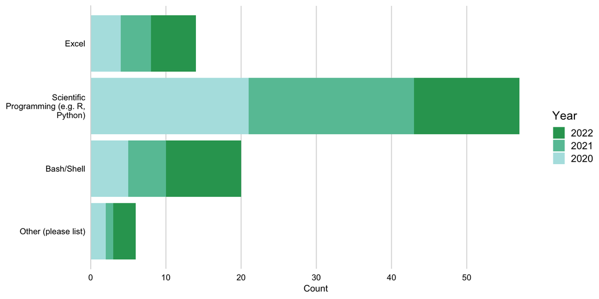

##### *Other (please list):*

| Matlab |
| --- |
| Jupyter Notebook |
| Use python for the merging of the files and then excel for the processing and display. |
| Google sheets |
| IDL |
| jupyter notebook |

##### *2.) Consider the tool(s) that you selected above - how comfortable are you implementing this task in that tool?*

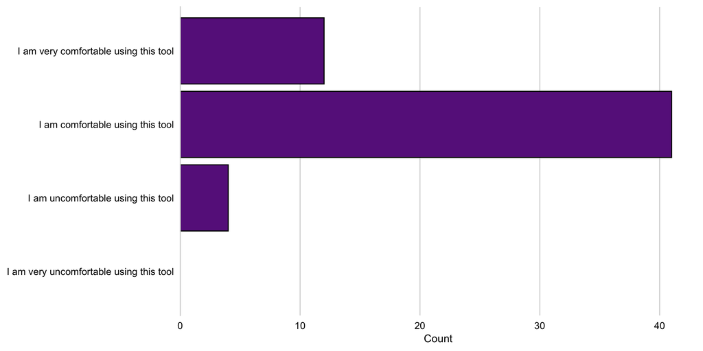

##### **3.) *Describe the steps (a step by step approach) that you would take to perform this analysis given the tools that you know how to use.***

Again students were asked to provide a step-by-step workflow outlining how they would use the data science tools of their choice to solve the problem described above. After completing the Bootcamp course students’ workflows are generally more detailed, and now frequently rely on loops, conditional statements, and other modular approaches to coding that prevent the use of repetetive steps, including the use of functions.

A for loop would make downloading/importing data quicker. Then depending on the tool, either using conditional statements to determine the month and calculating the mean, or using Python’s summary capabilities to do the same seems easy enough.

Python (more effective way) 1) Import packages (e.g. os, matplotlib.pyplot, numpy/pandas, earthpy) 2) Create a function to convert temperatures from F to C 3) Download/Define Paths/Import Data 4) Combine the .csv files (I would probably do this over looping) 5) Run the temperature function to convert to C 6) Summarize the data using means for each month across years 7) Plot

Excel (super long way) 1) Copy/paste each .csv file into a single file 2) Write an equation to find the average of each month per year

import data convert units calculate means plot

Download imports in python, write function o download each 32 files, and then get the monthly data for each month then graph it

In excel I would import the individual files and collate into one file then use function to calculate the summary data.  
In python (using jupyter notebook), I would create a function to import the txt files into one pandas dataframes (looked this up on stackoverflow), so that each month was one row (or column depending on txt format) of data. Next calculate monthly average across rows and copy into a new dataframe. These data are now ready to plot. Depending on what is in the file, I might need to create a list of months or set up the df as timeseries data before plotting.

I would first try to combine the 32 text files into one larger text file. I would be sure to organize the .txt so that the first row was the first year and the final row was the last year. I would then import this .txt file into a jupyter notebook python workflow. I would import the data to a numpy array. I would also consider importing it to a pandas Dataframe and insert headings for the months and years myself. I would then plot this data via Matplotlib.

import data find monthly max temps convert to celsius

1. read in the data
2. average across years and write into new data frame
3. plot data
1. Import packages/ modules

Download and import data.

Define functions for unit conversion and to take mean.

work with data as numpy array or data frames.

plot data with matplot lib.

Discuss results.

Using Python:

Load each text file into a numpy array.

Combine individual numpy arrays into a single array with all 32 years.

Compute the mean temperature of the numpy array, along the axis that produces the mean for each month.

Plot the mean data with matplotlib.pyplot.

I’d combine the text files into one to compare month’s to each other, download and import data, write functions for calculating the conversions and for plotting appropriately

Load packages, write function with a loop to calculate monthly average temperature across years and convert values to C, load data, put all text files in a list, run function on the list, plot data.

1. Open files and view raw data

Create a notebook

Import packages

Import data

Convert data to units needed

Create month list

Create and design plot

1. Assuming that I don’t have to do any data cleaning(a stretch, I know), put all text files into a single directory

Loop thru the text files and import them into pandas (unique df)

Merge all datasets using loop

Resample by month

df.mean(axis=0)

matplotlib

Import the document, assort it so we can easily manipulate the data, and plot it through matplotlib

> import the data into python > create function to convert Fahrenheit to Celcius > use loops to convert files & summarize data based on monthly mean > plot with matplotlib

Write a function to Download/import data into an array or Dataframe and the run a loop to do that. Write a function to do the math. Sorry, I have to board a flight so that’s it for now! But was worried I might lose this survey if I keep going here.

I would creat a function to download and import data. Then using this function in a loop, I would import all files and begin assigning datasets in my notebook. I would also use a function in a loop to summarize the data (find monthly average) and then finally plot summarized data.

Set working directory. Import data using a loop and extract arrays with index location of that list. Calculate monthly averages using np.mean and convert temperatures from Fahrenheit to Celsius with a defined function. I’m a little confused by the next requirement - it sounds like we need to have one graph per year of average monthly temp but it looks like we just need one graph. So, I think, we would next need to aggregate each of those arrays so that the average monthly temperatures are each columns with each of the 32 years as a row (would check shape after this). At that poiny we could average the monthly temperatures across all years and plot one graph with the months on the x axis and temperatures in celsius on the y axis.

I would write a function or use a for loop to read in all of the text files and combine them into one large data frame. I would probably use numpy and/or pandas to do this.

Ensure I have an environment and packages or libraries downloaded to work with. Locate and view the data, to review its structure. Set working directory for data and code Downlaod and import data into object Query and summarize data Plot data

I would: 1. Create a path to the 32 text files 2. Loop through the directory for the 32 files and import the data to a df while adding a column for the year-taken from the file name string 3. Using this new df I would subsample to a new df for monthly average temp 4. I would plot using matplot

Put the files in a directory

Examine the text file format- if they have month and day of month info I would use an approach that imports these information as fields. if the file is just a 1d array of temperature values, I would have to use a more labor intensive approach to subset the array for each year to create “month” and “day of month” values, paying special attention to leap years. Hopefully it is csv data that already has month and day of month values delimited!

Use Python in Jupyter Notebook to create a for loop to import/append data into a single dataframe that contains all the data, parsing the year info from the filename. The resultant product would be a pandas dataframe with columns “year”, “month”, “day_of_month”, and “temperature_deg_f”.

Next I would make a new dataframe series for “temperature_deg_c” by using a conversion factor.

The last processing step would be to make a dataframe object using groupby “month” with a .mean() calculation on the temperature_deg_c.

Then I would just plot that dataframe object as a line plot with month as the x axis and mean temp deg c as the y and add a marker symbol for each month.

FWIW, those data do not look right for Boulder, way too cold in the winter!- maybe Jackson, WY?

’- Use Jupyter Hub/ notebook on the cloud - Create home and file pathway - download data in a loop into a dataframe - look at and describe the data and its format - use a python loop to resample to monthly values, calculate mean, convert temp to Celsius and concat files into a dataframe - plot data with Matplotlib.pyplot

1. import needed packages, 2)download text files by, define variable to url, 3)provide variable as parameter (et.data.get_data) 4)set home directory and create path to files
2. import to a numpy array
3. convert degrees Fahr to degrees Celsius
4. create a figure from numpy array (define plot space, define x and y axis, set plot labels)

’- write for loop to read in each file and append to a single dataframe

- ensure date column is in datetime format, separate month from year if necessary
- write function to convert F to C and apply to temp Series data
- groupby month and calculate monthly average, resulting in new dataframe of monthly average temp in C
- use matplotlib.pyplot to plot monthly averages, including markers

I would import the data into a pandas dataframe and subset the data by monthly average. I’d run a conversion function specific to the temperature column to get degrees C, then plot using Matplotlib.

# PSEUDO CODE

import glob import matplotlib.pyplot as plt import os import pandas as pd

# Set proper current working directory

os.chdir(r’C:[remainder of path to current working directory]’)

# Import 32 text files to one consolidated DataFrame

all_data_df = pd.concat([pd.read_csv(file, sep=‘;’) for file in glob.glob("*.csv")], ignore_index=True)

# Create a new variable containing the daily temps in degrees Celsius

all_data_df[‘tempC’] = (all_data_df[‘tempF’] - 32) * (5/9)

# Set the date/time column as the DataFrame’s index

all_data_df.set_index(‘date_time’, inplace=True)

# Resample the data from daily temp observations to monthly avg temp observations

monthly_data_df = all_data_df[‘tempC’].resample(‘M’).mean()

# Plot temperature over time

ax = monthly_data_df.plot() ax.set_ylabel(‘Temperature (Celsius)’) plt.show()

I would create a function to summarize each txt file and then compile the monthly temperatures for each year into a pandas dataframe. I would then calculate the average monthly temperature across all years and plot this up.

I could complete this task in Excel, but because it would be very cumbersome to do so in that program, I would try to do it in Python with the skills we learned in class. Since working with “real-world” data always causes hang-ups that don’t exist in the classroom, I expect this would also take quite a bit of time, but it would be more useful in the long run to struggle with Python code and eventually learn faster/more versatile techniques.

1. load the data.
2. review and validate the data.
3. present the data.
4. ensure all steps are easily understandable and easy to replicate.

I would write a function that opens a csv into a pandas dataframe and coverts the temperature to Celsius.

I would then write a loop with that function to open every file into a single dataframe.

Then I would use groupby(“month”) .mean() to get average temps.

I would activate the earth-analytics-python conda environment in my shell and set my current directory to my desired working directory, then activate jupyter notebook. In a new notebook I would:

1. import the necessary packages (os, numpy, pandas, earthpy, matplotlib, etc.)
2. make a variable for the working directory I want and write a conditional statement to a) check that it exists, and b) if not, create it. Then set that working directory.
3. Download the data with earthpy (if necessary)
4. define a general path to the data, utilizing my working directory variable from above, and specifying the parent folder I expect the data to be in (earthpy-downloads)
5. write a function that loops through the directory, imports each .csv file, and appends it to an (initially empty) list of dataframes, then concatenates that list into a singular pandas dataframe containing the data from all of the files.
6. add a column to the dataframe and fill it with temperature data converted to Celsius from Fahrenheit (something like df[‘celsius’]=(df[‘fahrenheit’]-32)*(5/9) )
7. use .split() to extract the year and numeric month from the ‘date’ column or file name and add the extracted results as their own column (assuming they’re not already separate columns)
8. use .groupby() to subset data and .mean() to grab the monthly mean temperature across time
9. plot the data using pyplot (.plt, ax.plot)
10. give the plot a title and axes legends with ax.set()
1. import necessary packages
2. set working directory
3. set data path to text file
4. loop through the year of data needed
5. review the data
6. get the average monthly temperatures
7. plot the data for all months
1. Import the packages needed to manipulate and plot the data
2. Write function to import an individual file and grab the year in the file name and create a dataframe. And write a function to convert F to Celsius
3. Set the working directory
4. Name the path where the data are located
5. Write a for loop that applies the function written above to the 32 files that are listed using the glob function
6. Concatenate the individual dataframes into a single dataframe - make sure that the dataframe is indexed on the date
7. Covert temperature to Celsius using the function above
8. Use the groupby function to group by month and resample and calculate the mean temperature across years in a new dataframe.
9. Use this dataframe to create the plot using matplotly. The y-axis is the mean monthly temperature across the 32 years and the x-axis is the month.

’+ Read files into a date-indexed dataframe using a Jupyter Notebook

- Review data in notebook to catch nulls, etc.
- Resample to monthly
- Plot using matplotlib

Sometimes I look at source files with Excel.

Starting with Python: Create a loop that: 1) Adds a year column to each file and fills it with the year from the file name 2) Depending on the data also create a month column if needed (numerical or abbreviation does not matter) 3) Appends all of the files together into a list

Concatenate all the files and create a new data frame Save the data frame as a csv

Switching to Excel open saved csv build VBA code that, in a new table (could do this in python, but excel enables me to have more control to make sure that I am accurately manipulating the data): 1) gets the mean value for each month 2) converts the results to Celsius

Then use excel graphing abilities to make a more professional looking graph compared to python

n/a

’- Open file as csv - plot with matplotlib - set axis - define color

I would import the data using pandas read_csv and then use loops (maybe a function defining loops, depends if this is something I will have to do frequently) to combine the files.

I would then use resample to get the monthly values and basic arithmetic to convert to celsius. Finally, I would use matplotlib to plot.

’- Link to file fold - QA/QC - Make list of files names - Use a loop to: 1. Import files into a single DataFrame, 2. Set DateTime as index - Use a for loop to find the average temperature for n = month, where month = [1,2,3…12], and create a new dataframe from these data - Plot monthly averages using pyplot

Loop through the text files, add them to a dataframe. Use time series and groupby to group by month and calculate the mean across all years. Plot using matplotlib

hold

1. Stage data
2. Clean data
3. Analyze data
4. Graph data

n/a

In Python

- get a list of the files
- loop over the files, append the data to a list - parse and index by date
- turn that list into a dataFrame, i.e. df.concat(list_of_files, axis=0)
- resample to monthly means, i.e. df.resample(‘MS’).mean()
- assign month to a column
- group by month and take the mean, i.e. df.groupby(‘month’).mean()
- plot with x=df.month_name, y=df.temperature

Write a function to open the csv files and create a data frame to store the temperature data. Resample the daily data to monthly average data. Use matplotlib to plot the data.

‚Ä¶..

I would use jupyter notebook, to write few blocks of code, which would download the data, merge it into one data frame, convert to C, summarize and plot it

Impost csv Define function to make modular code that iterates through all the 32‚Äô files and does mathematic conversion and for loop to make a dataframe, and plot the data.

TERMINAL Use terminal to activate Conda and open new Jupyter Notebook CODE IN PYTHON Set home directory, get data and save locally Write loop to open each file and save data into combined data frame for all years. Calculate average monthly temp for all years (12 values, one per month) Graph this info

Create a function that loops through .csv datasets within a directory. Create a output dataframe that appends each of the csv files together into an empty list.

Plot the dataframe using .plot.

Open bash Open the notebook in the platform desired Create the path to the information needed Resample data to get the information to graph Write the plot code Run the plot to see if it worked.

After downloading all the necessary packages, I would import the text files using pandas and create a dataframe with month columns and a row for every year. Next I would convert the Fahrenheit data to degrees Celsius, and then take the average monthly sum of each month column. Lastly I would plot the data as a line plot similar to the plot above.

Excel: put the data in a graph

Import or download data, set data paths, open files, create dataframes, subset or resample data for desired dates and monthly averages. Plot using matplotlib.

I would write a function to import a single file via python code and extract the data to a pandas dataframe. I’d write another function for converting fahrenheit to celsius. Then I would write a loop to perform the import function on all of the files I needed, add a column with temperature in celsius, and I’d concat them all into a single dataframe. Then I’d plot all the data over time.

### Discussion

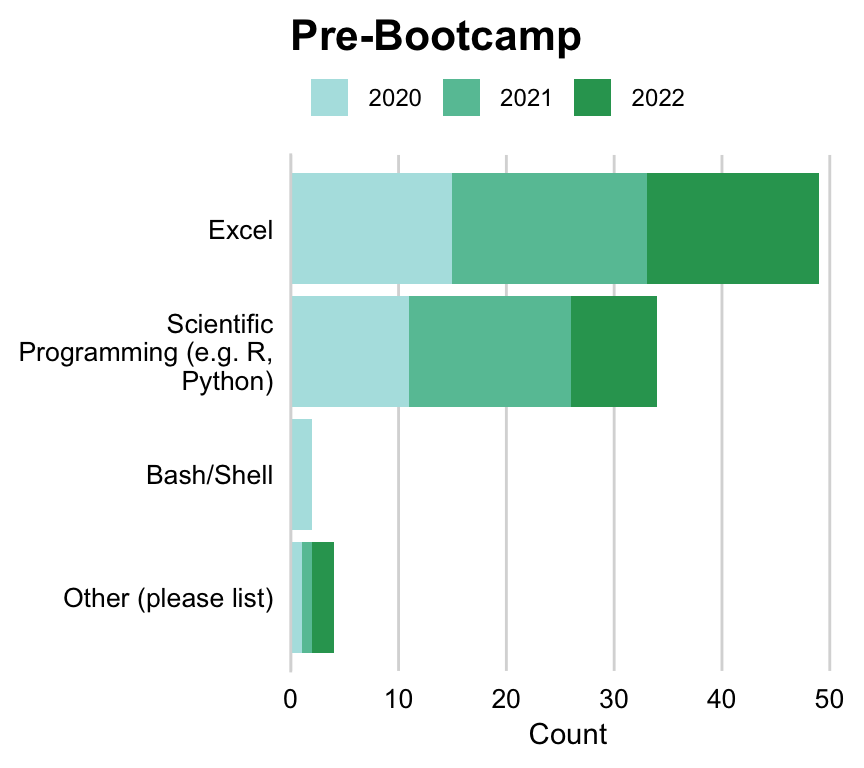

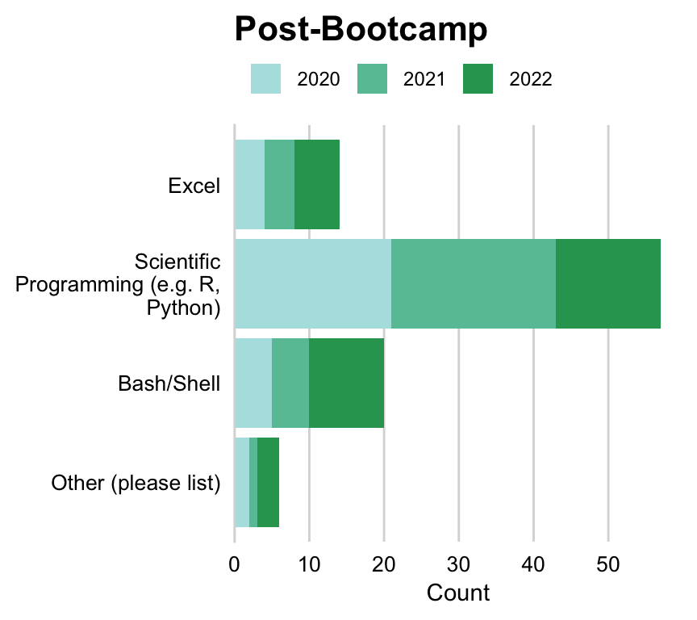

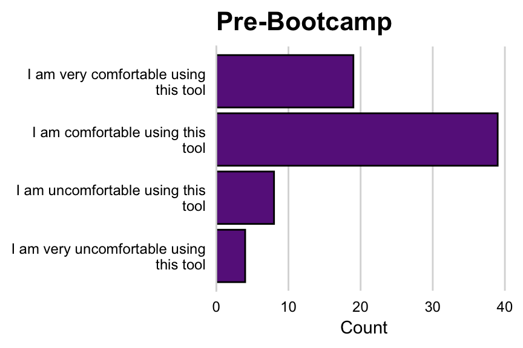

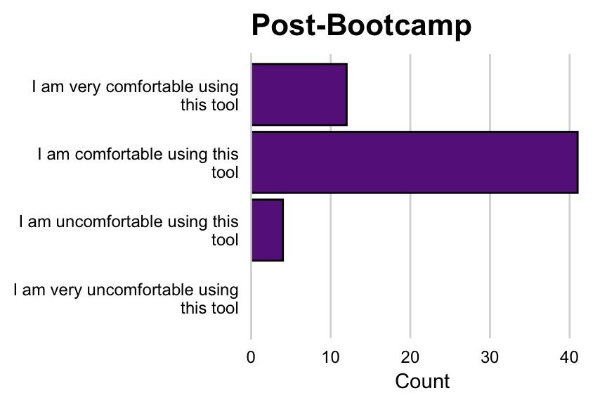

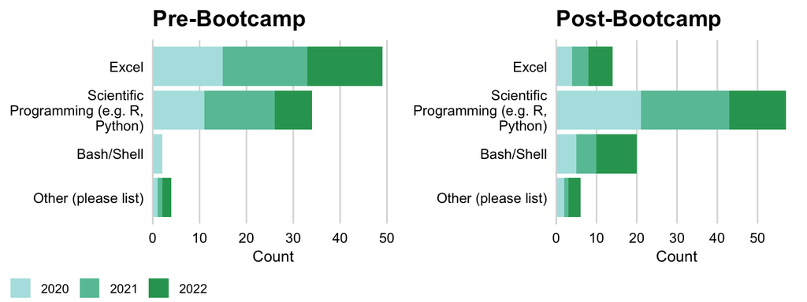